# UNCBreastAnalysis

John Steinman

7/9/2019

## Objective

The objective of this project is to recreate figure 3 from “Statistical Significance for Hierarchical Clustering” (Kimes et al. 2017). In this paper, the authors use the SigClust2 function on a microarray gene expression dataset of 337 BRCA samples. These samples were obtained from the University of North Carolina (UNC) Microarray Database. Their results are shown below.

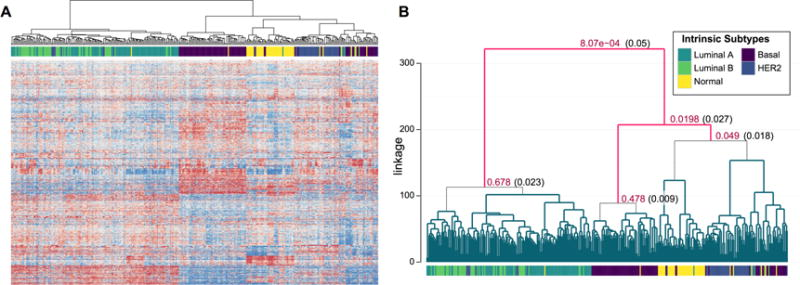

Figure 3. Analysis of gene expression for 337 BRCA samples. (A) Heatmap of gene expression for the 337 samples (columns) clustered by Ward’s linkage. (B) Dendrogram with corresponding SHC p -values and α * cutoffs given only at nodes tested according to the FWER controlling procedure at α = 0.05.

## Data Cleaning

Kimes used the data-processing techniques outlined in “Phenotypic and molecular characterization of the claudin-low intrinsic subtype of breast cancer” (Prat et al. 2010). The methods are as follows:

> The probes or genes for all analyses were filtered by requiring the lowest normalized intensity values in both sample and control to be > 10. The normalized log2 ratios (Cy5 sample/Cy3 control) of probes mapping to the same gene (Entrez ID as defined by the manufacturer) were averaged to generate independent expression estimates. In the resulting UNC337 matrix, no significant batch effects were observed…In all data sets, genes were median-centered within each data set and samples were standardized to zero mean and unit variance before other analyses were performed.

Since the gene screening techniques used in the paper yielded little change (filtered 10 of 1655 genes), I neglected this step. I also omitted 3 samples whose Pam 50 prognoses were unknown, making my data 1655 x 334.

```r
#READ DATA
dat<-read.table("UNCBreastRna.cdt", header = TRUE, sep = "", fill = TRUE)
dat<-dat[,1:(ncol(dat)-1)]

#Remove Headers
sub_dat<-dat[7:nrow(dat), 5:338]
sub_dat = matrix(as.numeric(as.matrix((sub_dat))), nrow = nrow(sub_dat), ncol = ncol(sub_dat))
rownames(sub_dat)<-dat[7:nrow(dat),1]
colnames(sub_dat)<-colnames(dat)[5:338]

summary(as.numeric(as.character(sub_dat)))  #5 number summary
```

```
##    Min. 1st Qu.  Median    Mean 3rd Qu.    Max.
## -7.1700 -0.4050  0.0000  0.0469  0.4400  9.1600
```

```r
#Store Pam_50
pam_50 = as.factor(as.matrix(dat[4,5:338])); rownames(pam_50) = NULL; colnames(pam_50) = NULL;
summary(pam_50)
```

```
##  Basal   Her2   LumA   LumB Normal
##     90     42    100     63     39
```

```r
pam_50 = t(as.data.frame(pam_50))
```

The genes appeared to already be median centered, so I proceeded to standardize the columns.

```r
dat_std = scale(sub_dat) #center and scale samples
```

## Heatmap

To generate the heat maps like in figure 3, I used the R package ‘complexheatmap.’ It uses a hierarchical agglomerative clustering algorithm to cluster the rows and columns. I used euclidean distance metric and ward.D2 linkage method.

```r
col_fun = colorRamp2(c(-2, 0, 2), c("blue", "white", "red")) #colors for gene expression
pam_names = c("Normal", "Basal", "Her2", "LumB", "LumA")
pam_colors = structure(1:5, names = pam_names)               #colors for Pam 50

ht= Heatmap(dat_std, name = "Gene Expression", col = col_fun,
            clustering_distance_columns = "euclidean",  clustering_method_columns = "ward.D2",
            clustering_distance_rows = "euclidean", clustering_method_rows = "ward.D2",
            show_row_dend = FALSE, show_row_names = FALSE, show_column_names = FALSE,
            width = unit(14, "cm"), height = unit(10, "cm"))
```

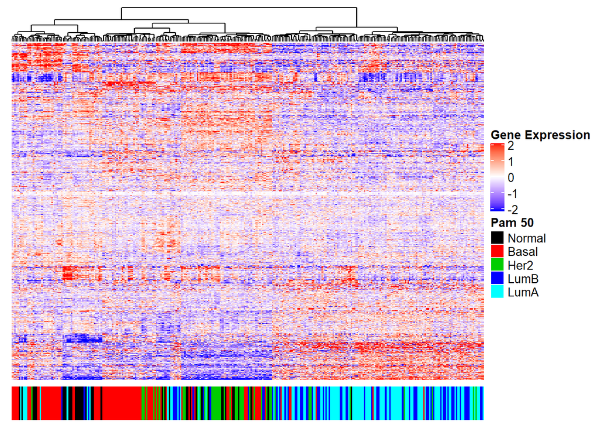

```r
pam_50_ordered = t(pam_50[column_order(ht_draw)])
ht2 = Heatmap(pam_50_ordered, name = "Pam 50",col = pam_colors,
              width = unit(14, "cm"), height = unit(1, "cm"))
ht_list = ht %v% ht2
ht_list_draw = draw(ht_list)
```

The resulting heat map is similar to the one if figure 3. The luminal groups seem to be difficult to separate.

## SigClust2 Results

I performed SigClust2 of the data, again using euclidean metric and ward.D2 linkage method. The results are as shown below.

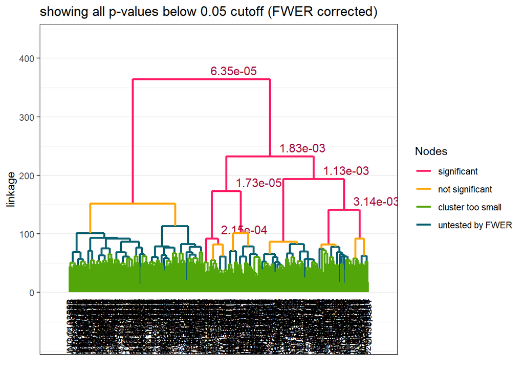

```r
t = t(dat_std) #transpose data; shc performs clustering on rows
shc_result = shc(t, metric = "euclidean", linkage = "ward.D2")
plot(shc_result)
```

SigClust2 detected more significant clusters in my application than were shown in figure 3.